# Marketing Campaign A/B Testing

A fast-food chain plans to add a new item to its menu. However, they are still undecided between three possible marketing campaigns for promoting the new product. In order to determine which promotion has the greatest effect on sales, the new item is introduced at locations in several randomly selected markets. A different promotion is used at each location, and the weekly sales of the new item are recorded for the first four weeks.

1. Import Data and Libraries
2. Data Validation
3. Data Exploration
4. Anova
5. Non-Parametric Anova

## 1. Import Data and Libraries

```python
#Import Libraries
import pandas as pd
import seaborn as sns
import matplotlib.pyplot as plt
import numpy as np
from statsmodels.graphics.gofplots import qqplot
from scipy.stats import shapiro, levene, kruskal

# Read in `road-accidents.csv`
df= pd.read_csv('WA_Marketing-Campaign.csv')

# Save the number of rows columns as a tuple
rows_and_cols = df.shape
print('There are {} rows and {} columns.\n'.format(
    rows_and_cols[0], rows_and_cols[1]))

# Generate an overview of the DataFrame
df_info = df.info()
print(df_info)

# Display the last five rows of the DataFrame
df.head()
```

```
There are 548 rows and 7 columns.

<class 'pandas.core.frame.DataFrame'>
RangeIndex: 548 entries, 0 to 547
Data columns (total 7 columns):
 #   Column            Non-Null Count  Dtype
---  ------            --------------  -----
 0   MarketID          548 non-null    int64
 1   MarketSize        548 non-null    object
 2   LocationID        548 non-null    int64
 3   AgeOfStore        548 non-null    int64
 4   Promotion         548 non-null    int64
 5   week              548 non-null    int64
 6   SalesInThousands  548 non-null    float64
dtypes: float64(1), int64(5), object(1)
memory usage: 30.1+ KB
None
```

|  | MarketID | MarketSize | LocationID | AgeOfStore | Promotion | week | SalesInThousands |
| --- | --- | --- | --- | --- | --- | --- | --- |
| 0 | 1 | Medium | 1 | 4 | 3 | 1 | 33.73 |
| 1 | 1 | Medium | 1 | 4 | 3 | 2 | 35.67 |
| 2 | 1 | Medium | 1 | 4 | 3 | 3 | 29.03 |
| 3 | 1 | Medium | 1 | 4 | 3 | 4 | 39.25 |
| 4 | 1 | Medium | 2 | 5 | 2 | 1 | 27.81 |

## 2. Data Validation

```python
#null values
missing= df.isna().sum() # no null
print(missing)

#duplicated values
print(df.duplicated().sum())

print(df.nunique()) # of unqiue values

print(df.shape[0]) # of rows
```

```
MarketID            0
MarketSize          0
LocationID          0
AgeOfStore          0
Promotion           0
week                0
SalesInThousands    0
dtype: int64
0
MarketID             10
MarketSize            3
LocationID          137
AgeOfStore           25
Promotion             3
week                  4
SalesInThousands    517
dtype: int64
548
```

```python
#drop redundant features
df.drop(['LocationID','MarketID'], axis=1, inplace=True)
```

```python
#Check Data types
df.dtypes
```

```
MarketSize           object
AgeOfStore            int64
Promotion             int64
week                  int64
SalesInThousands    float64
dtype: object
```

```python
#Convert cont to cat
list=['week', 'Promotion']
for x in list:
    df[x]=df[x].astype(str)
df.dtypes
```

```
MarketSize           object
AgeOfStore            int64
Promotion            object
week                 object
SalesInThousands    float64
dtype: object
```

```python
#Categorical Feature groups
for x in cat_col:
    print(df[x].unique())
```

```
['Medium' 'Small' 'Large']
['3' '2' '1']
['1' '2' '3' '4']
```

## 3. Data Exploration

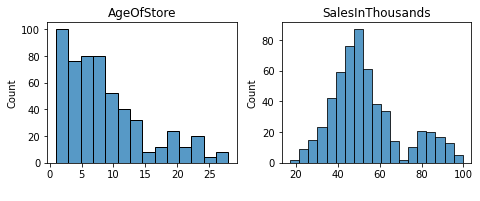

```python
#cont features
cont = df.select_dtypes(['int64','float64'])
fig = plt.figure(figsize = (10,5))
for x, y in enumerate(cont):
    ax = fig.add_subplot(2,3,x+1)
    ax = sns.histplot(df , x = y)
    ax.set_title(y)
    ax.set_xlabel(' ')
plt.tight_layout()
plt.show()
```

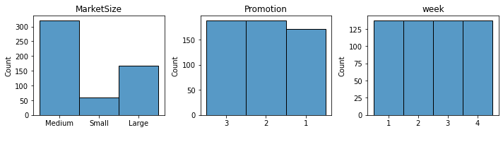

```python
cat = df.select_dtypes('object')
fig = plt.figure(figsize = (10,5))
for x,y in enumerate(cat):
    ax = fig.add_subplot(2,3,x+1)
    ax = sns.histplot(df , x = y)
    ax.set_title(y)
    ax.set_xlabel(' ')
plt.tight_layout()
plt.show()
```

### Sales

```python
#inspect sales features
df['SalesInThousands'].describe()
```

```
count    548.000000
mean      53.466204
std       16.755216
min       17.340000
25%       42.545000
50%       50.200000
75%       60.477500
max       99.650000
Name: SalesInThousands, dtype: float64
```

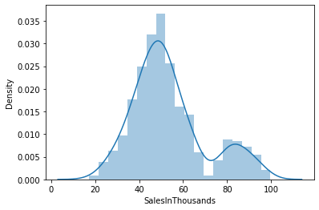

```python
sns.distplot(df['SalesInThousands'])
plt.show()
```

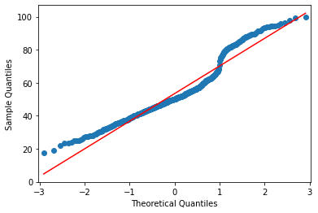

```python
import statsmodels.api as sm
sm.qqplot(df["SalesInThousands"],line='s')
plt.show()
```

```python
import numpy as np
from scipy.stats import shapiro

p_value = shapiro(df['SalesInThousands'])
print(p_value[1])
```

```
9.384886192286522e-15
```

**INSIGHT:** The sample violates the assumption that the data is Normally distributed therefore results of ANOVA may be unreliable. Non-Parametric methods can provide accurate results for data that violate assumptions of normality.

### Promotions

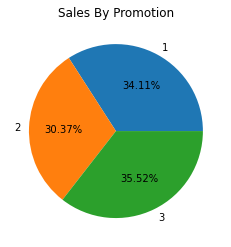

```python
# Sales proportion by promotion type
df.groupby('Promotion')['SalesInThousands'].sum().plot(title='Sales By Promotion', kind='pie', autopct='%0.2f%%')
plt.ylabel('')
plt.show()
```

```python
# Summary stats of sales by promotion type
df.groupby('Promotion')['SalesInThousands'].agg(['mean','std','count'])
```

| Promotion | mean | std | count |
| --- | --- | --- | --- |
| 1 | 58.099012 | 16.553782 | 172 |
| 2 | 47.329415 | 15.108955 | 188 |
| 3 | 55.364468 | 16.766231 | 188 |

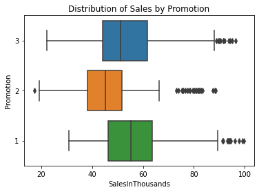

```python
# Boxplots of sales by promotion type
sns.boxplot(x='SalesInThousands',y= 'Promotion', data=df)
plt.title('Distribution of Sales by Promotion')
plt.show()
```

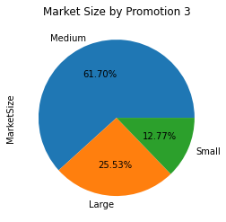

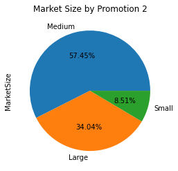

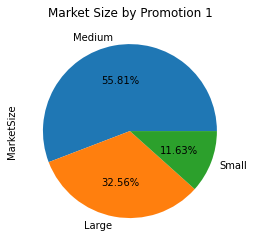

```python
# Market size by promotion type
prom=df['Promotion'].unique()
for x in prom:
    df[df['Promotion']==x]['MarketSize'].value_counts().plot(title='Market Size by Promotion ' + x, kind='pie', autopct='%0.2f%%')
    plt.show()
```

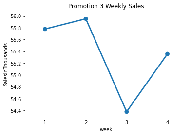

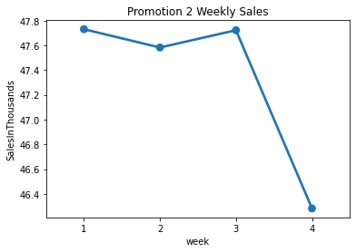

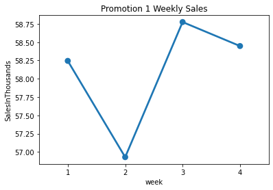

```python
# Weekly sales by promotion type
for x in prom:
    sns.pointplot(x='week', y='SalesInThousands', data=df[df['Promotion']==x], title= 'Promotion' + x, ci=False)
    plt.title('Promotion '+ x + ' Weekly Sales')
    plt.show()
```

**Insight:** Distribution, sum and mean of Sales by Promotion type clear differences, however we must do statistical tests to confirm whether the differences are significant or just by chance. The pie chat shows that market size is somewhat consistent for each promotion type. Weekly sales pointplots may look volatile if you do not look at the sales total in the y-axis.

## ANOVA

**HO:** There is not a difference in Mean Sales for the three Promotions  
**Ha:** There is a significant difference in mean Sales between one or more of the Promotions

```python
# Install libraries for anova
pip install --upgrade pingouin
```

```python
#ANOVA
import pingouin as pg

anova_results = pg.anova(data=df,
                               dv="SalesInThousands",
                               between="Promotion")

# Print anova_results
print(anova_results)
```

```
      Source  ddof1  ddof2          F         p-unc       np2
0  Promotion      2    545  21.953486  6.765849e-10  0.074557
```

**RESULTS:** The ANOVA results show P-value is below .05 alpha. Reject the null hyopthesis, there is a significant difference in Sales between one or more of Promotions.

```python
#Pairwise test to find sig differences between each Promotion
pg.pairwise.pairwise_tests(data=df, dv='SalesInThousands', between= "Promotion", padjust='bonf',alternative='greater')
```

|  | Contrast | A | B | Paired | Parametric | T | dof | alternative | p-unc | p-corr | p-adjust | BF10 | hedges |
| --- | --- | --- | --- | --- | --- | --- | --- | --- | --- | --- | --- | --- | --- |
| 0 | Promotion | 1 | 2 | False | True | 6.427529 | 346.783619 | greater | 2.145184e-10 | 6.435553e-10 | bonf | 4.089e+07 | 0.679522 |
| 1 | Promotion | 1 | 3 | False | True | 1.556022 | 355.918164 | greater | 6.029574e-02 | 1.808872e-01 | bonf | 0.745 | 0.163744 |
| 2 | Promotion | 2 | 3 | False | True | -4.881393 | 374.000000 | greater | 9.999992e-01 | 1.000000e+00 | bonf | 6.026e-05 | -0.502467 |

### Non-Parametric ANOVA

```python
# Kruskal-Wallis ANOVA

kw_test = pg.kruskal(data=df,
                           dv='SalesInThousands',
                           between='Promotion')
print(kw_test)
```

```
            Source  ddof1          H         p-unc
Kruskal  Promotion      2  53.294752  2.674187e-12
```

**RESULTS:** The Kruskal-Wallis ANOVA results show P-value is below .05 alpha. Reject the null hyopthesis, there is a significant difference in Sales between one or more of Promotions.

```python
#Transformation for Wilcoxon-Mann-Whitney
df1 = df[['SalesInThousands', 'Promotion']]

# Convert df1 into wide format
df1_wide = df1.pivot(columns='Promotion', values='SalesInThousands')
df1_wide
```

| Promotion | 1 | 2 | 3 |
| --- | --- | --- | --- |
| 0 | NaN | NaN | 33.73 |
| 1 | NaN | NaN | 35.67 |
| 2 | NaN | NaN | 29.03 |
| 3 | NaN | NaN | 39.25 |
| 4 | NaN | 27.81 | NaN |
| ... | ... | ... | ... |
| 543 | 64.34 | NaN | NaN |
| 544 | NaN | 50.20 | NaN |
| 545 | NaN | 45.75 | NaN |
| 546 | NaN | 44.29 | NaN |
| 547 | NaN | 49.41 | NaN |

548 rows × 3 columns

```python
# Wilcoxon-Mann-Whitney test to find diffence between each promotion

wmw_test1 = pg.mwu(x=df1_wide['1'],
                        y=df1_wide['2'],
                        alternative='greater')

wmw_test2 = pg.mwu(x=df1_wide['1'],
                        y=df1_wide['3'],
                        alternative='greater')

wmw_test3 = pg.mwu(x=df1_wide['2'],
                        y=df1_wide['3'],
                        alternative='greater')

# Print the test results
print(wmw_test1)
print(wmw_test2)
print(wmw_test3)
```

```
       U-val alternative         p-val       RBC      CLES
MWU  22957.5     greater  2.922968e-12 -0.419934  0.709967
       U-val alternative     p-val       RBC      CLES
MWU  18247.0     greater  0.017542 -0.128587  0.564294
       U-val alternative  p-val       RBC      CLES
MWU  12093.0     greater    1.0  0.315697  0.342151
```

**RESULTS:** The Wilcoxon-Mann-Whitney test results show P-value is below .05 alpha for two of the three comparisons. The most successful promotion based on sales was promotion 1, followed by promotion 3. Promotion 2 was the least successful.

### Conclusion

The sample violates the assumption that the data is normally distributed therefore Non- Parametric methods were used. The Krusal-Wallis ANOVA results show the P-value is below .05 alpha. Reject the null hyopthesis, there is a significant difference in Sales between one or more of Promotions. The Wilcoxon-Mann-Whitney test results show P-value is below .05 alpha for two of the three comparisons. The most successful promotion based on sales was promotion 1, followed by promotion 3. Promotion 2 was the least successful.